# Thermal_traits_metaanalysis_protocol

Darío San Segundo Molina, Sara Villén Pérez & Ignacio Morales Castilla

19/1/2022

# Individual-study approach:

## Thermal traits pest database:

Thermal traits database (from now on: *TheTraPest*) have been obtained after several steps:

1. Literature systematic review
2. Data preparation: *Intrapest* database assembly.
3. Generalized Nonlinear Regression with `nlme::gnls()`
4. Parameter extraction and *TheTraPest* database assembly.

| a_est | a_se | tmin | tmin_se | tmax | tmax_se | topt | topt_se | start_a | start_tmin | start_tmax | id | authors | Year | title | DOI | vi | order | family | genus | species | feeding_guild | lat | sd_median | thermal_breadth | t50_left | t50_right | tol_range | thermal_safety_margin |
| --- | --- | --- | --- | --- | --- | --- | --- | --- | --- | --- | --- | --- | --- | --- | --- | --- | --- | --- | --- | --- | --- | --- | --- | --- | --- | --- | --- | --- |
| 7.06789198794233e-05 | 7.52087434783839e-06 | 3.24677435696439 | 1.21703982336665 | 33.2917535659864 | 0.35206208038712 | 26.9788677937295 | 0.282693787569012 | 6e-05 | 1 | 33.5 | 1 | de Campos | 2021 | Thermal biology ofTuta absoluta:demographic parameters and facultative diapause | 10.1007/s10340-020-01286-8 | 0.00789 | Lepidoptera | Gelechiidae | Tuta | absoluta | borer | 42.6391 | 0.049900741477457 | 17.7575 | 15.5342 | 33.2917 | 30.044979209022 | 6.31288577225689 |
| 7.87010350577536e-05 | 8.47028744086477e-06 | 3.58079249913107 | 1.24287368964598 | 33.3577549234519 | 0.353312604787046 | 27.0696440598091 | 0.281898670960004 | 8e-05 | 4 | 33.5 | 1 | de Campos | 2021 | Thermal biology ofTuta absoluta:demographic parameters and facultative diapause | 10.1007/s10340-020-01286-8 | 0.00789 | Lepidoptera | Gelechiidae | Tuta | absoluta | borer | 42.6391 | 0.049900741477457 | 17.6825 | 15.6752 | 33.3577 | 29.7769624243208 | 6.28811086364281 |
| 7.47583233238545e-05 | 8.19984143501001e-06 | 4.37016217738809 | 1.2235240400936 | 33.2668264786595 | 0.308074908305308 | 27.0888216754755 | 0.256973486633185 | 7e-05 | 4 | 33.5 | 1 | de Campos | 2021 | Thermal biology ofTuta absoluta:demographic parameters and facultative diapause | 10.1007/s10340-020-01286-8 | 0.00789 | Lepidoptera | Gelechiidae | Tuta | absoluta | borer | 42.6391 | 0.049900741477457 | 17.3576 | 15.9092 | 33.2668 | 28.8966643012714 | 6.17800480318401 |
| 9.21559445899064e-05 | 8.92232166915138e-06 | 6.13432292338738 | 0.933809807996849 | 33.3337523068506 | 0.315283126210767 | 27.3578915005009 | 0.25353109464434 | 9e-05 | 6 | 33.5 | 1 | de Campos | 2021 | Thermal biology ofTuta absoluta:demographic parameters and facultative diapause | 10.1007/s10340-020-01286-8 | 0.00789 | Lepidoptera | Gelechiidae | Tuta | absoluta | borer | 42.6391 | 0.049900741477457 | 16.7447 | 16.589 | 33.3337 | 27.1994293834632 | 5.97586080634965 |
| 6.93415717491874e-05 | 7.98708154381534e-06 | 2.63640669622102 | 1.41918988271776 | 33.374362757145 | 0.379083795608755 | 26.9766754080204 | 0.30135013359979 | 7e-05 | 3 | 33.5 | 1 | de Campos | 2021 | Thermal biology ofTuta absoluta:demographic parameters and facultative diapause | 10.1007/s10340-020-01286-8 | 0.00789 | Lepidoptera | Gelechiidae | Tuta | absoluta | borer | 42.6391 | 0.049900741477457 | 18.0047 | 15.3696 | 33.3743 | 30.737956060924 | 6.39768734912457 |
| 7.63224978979102e-05 | 8.63228941090065e-06 | 3.23892313827546 | 1.31609613780266 | 33.5275337379452 | 0.44241876781813 | 27.1664513183244 | 0.339067686948754 | 8e-05 | 4 | 33.5 | 1 | de Campos | 2021 | Thermal biology ofTuta absoluta:demographic parameters and facultative diapause | 10.1007/s10340-020-01286-8 | 0.00789 | Lepidoptera | Gelechiidae | Tuta | absoluta | borer | 42.6391 | 0.049900741477457 | 17.8936 | 15.6339 | 33.5275 | 30.2886105996697 | 6.36108241962079 |
| 7.38248046364038e-05 | 7.99729788869568e-06 | 2.69598785686333 | 1.24231401480546 | 33.5314997945278 | 0.482408115024335 | 27.1089059450704 | 0.366884028581251 | 9e-05 | 5 | 33.5 | 1 | de Campos | 2021 | Thermal biology ofTuta absoluta:demographic parameters and facultative diapause | 10.1007/s10340-020-01286-8 | 0.00789 | Lepidoptera | Gelechiidae | Tuta | absoluta | borer | 42.6391 | 0.049900741477457 | 18.0742 | 15.4572 | 33.5314 | 30.8355119376645 | 6.42259384945744 |
| 6.90552606932567e-05 | 9.11970280156632e-06 | 1.83873937886654 | 1.59202538566225 | 33.9173311769513 | 0.699586084404691 | 27.3241410604322 | 0.515780325057389 | 9e-05 | 5 | 33.5 | 1 | de Campos | 2021 | Thermal biology ofTuta absoluta:demographic parameters and facultative diapause | 10.1007/s10340-020-01286-8 | 0.00789 | Lepidoptera | Gelechiidae | Tuta | absoluta | borer | 42.6391 | 0.049900741477457 | 18.5637 | 15.3536 | 33.9173 | 32.0785917980848 | 6.59319011651918 |
| 5.74809560823369e-05 | 8.6040530150731e-06 | 0.999841481443151 | 1.92639780748607 | 33.7211503801969 | 0.71245871788151 | 27.0787850499383 | 0.529233359024987 | 6e-05 | 1 | 33.5 | 1 | de Campos | 2021 | Thermal biology ofTuta absoluta:demographic parameters and facultative diapause | 10.1007/s10340-020-01286-8 | 0.00789 | Lepidoptera | Gelechiidae | Tuta | absoluta | borer | 42.6391 | 0.049900741477457 | 18.7075 | 15.0136 | 33.7211 | 32.7213088987537 | 6.64236533025856 |
| 7.09481083996672e-05 | 8.07310012382609e-06 | 2.43139646713138 | 1.3894780182318 | 33.7197343219283 | 0.495759569118263 | 27.2302893600599 | 0.37025488549315 | 8e-05 | 4 | 33.5 | 1 | de Campos | 2021 | Thermal biology ofTuta absoluta:demographic parameters and facultative diapause | 10.1007/s10340-020-01286-8 | 0.00789 | Lepidoptera | Gelechiidae | Tuta | absoluta | borer | 42.6391 | 0.049900741477457 | 18.2657 | 15.454 | 33.7197 | 31.2883378547969 | 6.4894449618684 |

[output cut: 4110 more lines]

## Background on meta-analyses and thermal-traits modelling procedures:

#### Statistical models:

We follow considerations of other recent meta-analytical hierarchical models that have been carried out for physiological traits as it is our case (Buckley et al. 2017, Kharouba et al. 2018, Ettinger et al. 2020). Similarly, except for origin of the data, similar hierarchical models have been used for thermal traits variability (Herrando-Pérez et al. 2020); whereas other approaches used more complex analyses such as random forest (Bennett et al. 2021).

All models were considered for meta-analysis following existing guidelines in Maximum likelihood (Mengersen and Schmid 2013) and Bayesian Inference approaches (Schmid and Mengersen 2013) on a mixed-effect modelling baseline (Zuur et al. 2009).

## Analyses: methods

#### Exploratory data analysis

We examine whether outliers should be remove. We select those whose parameter’s standard error is lower than Q<sub>95.</sub> The dataset that we load here has been already filtered this way, and thermal breadth has also been calculated (see thermal_traits_analysis_sideB.R script)¿Seguir indicaciones de Harr…? Model asssumptions:

Meta-analysis classical methodologies relies on assumptions of normality of the parameter estimates when a non standard effect size metric is used (Koricheva et al. 2013). Consequently, we checked normality distribution of the parameters using histograms and Shapiro-tests and using `performance` package to check the model assumptions. These assumptions are not required to be accomplished in the Bayesian approach described below.

1. **Normality**:

Via histograms, without outliers:

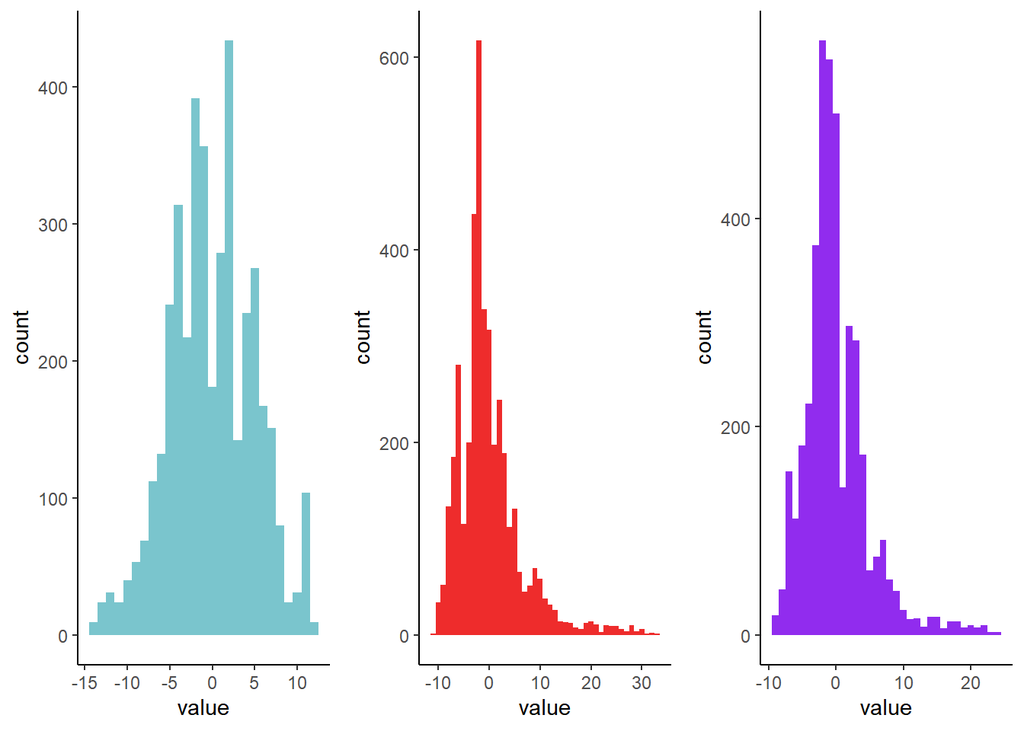

```r
#Tmin
lm_tmin <- lm(tmin ~ 1,
              data = thetrapest)
tmin_resid <- lm_tmin$residuals %>%
  as_tibble()

hist_Tmin_est <- ggplot(tmin_resid, aes(value))+
  geom_histogram(fill = "cadetblue3", binwidth = 1)+
  theme_classic()

#Tmax
lm_tmax <- lm(tmax ~ 1,
              data = thetrapest)
tmax_resid <- lm_tmax$residuals %>%
  as_tibble()

hist_Tmax_est <- ggplot(tmax_resid, aes(value))+
  geom_histogram(fill = "firebrick2", binwidth = 1)+
  theme_classic()

#Topt
lm_topt <- lm(topt ~ 1,
              data = thetrapest)
topt_resid <- lm_topt$residuals %>%
  as_tibble()

hist_Topt_est <- ggplot(topt_resid, aes(value))+
  geom_histogram(fill = "purple2", binwidth = 1)+
  theme_classic()
#a
lm_a <- lm(a_est~1,
            data = thetrapest)
a_resid <- lm_a$residuals %>%
  as_tibble()

grid_histo <- cowplot::plot_grid(hist_Tmin_est,hist_Tmax_est,hist_Topt_est,nrow = 1)
grid_histo
```

## Summary effects analysis:

We fitted a random-intercept mixed-effects model to assess thermal traitsvariability across studies with `lme()`. Note that in a meta-analysis context it is required to weight each study with inverse-variance. Thus, we use the given standard errors (`vi`) and incorporate them at the model with the argument `weights = varFixed(~vi)`. In addition, according to Viechtbauer, **`metafor`** package developer, in nlme package we need to add an argument `control = lmeControl(sigma = 1)` to tell the model that we *indeed* know the variances given at each study (*i.e.* the *sampling variances* representing the *within-studies* variance) and avoid its modelling.

> *“First of all, it’s good to see that you are well aware of the fact that lme() without lmeControl(sigma=1) will lead to the estimation of the residual variance component, which implies that the sampling variances specified via varFixed() are only assumed to be known up to a proportionality constant – however, in the usual meta-analytic models, we assume that the sampling variances are exactly known. In fact, trying to disentangle that residual variance component from any random study effects is usually next to impossible. I mention this explicitly one more time, because I have seen some publications using lme() in exactly this way …”* – Viechtbauer ([blog response](https://r-help.stat.math.ethz.narkive.com/ClFcC12h/r-mixed-effects-meta-regression-nlme-vs-metafor)).

And similarly, according to Heisterkamp (2017):

> *For some applications, it is not appropriate to estimate the residual error, especially when it is known in advance based on evidence from past studies, or a theoretically derived scaling parameter. An example of the former are meta-analyses where the standard deviation of individual patient outcomes in each study is reported.*

and Pustejovski (2016) in this [blog post](https://www.jepusto.com/bug-in-nlme-with-fixed-sigma/) :

> *About one year ago, the `nlme` package introduced a feature that allowed the user to specify a fixed value for the residual variance in linear mixed effect models fitted with `lme()`. This feature is interesting to me because, when used with the `varFixed()` specification for the residual weights, it allows for estimation of a wide variety of meta-analysis models, including basic random effects models, bivariate models for estimating effects by trial arm, and other sorts of multivariate/multi-level random effects models.*

In contrast, Koricheva et al. (2013) point out that nlme package directly gives an output for *between-studies* variance (i.e. random std. dev.) and *within-studies variance* (residuals std. dev.).

Synthesizing all of that, we fit a random-intercept model for thermal traits:

#### a) Tmin

```r
tmin_intercept <- lme(tmin ~ 1,
                      random = ~1|id,
                      weights = varFixed(~vi),
                      data = thetrapest,
                      control = lmeControl(sigma = 1))
summary(tmin_intercept)
```

```
## Linear mixed-effects model fit by REML
##   Data: thetrapest
##        AIC      BIC    logLik
##   845490.7 845503.3 -422743.3
##
## Random effects:
##  Formula: ~1 | id
##         (Intercept) Residual
## StdDev:    5.176878        1
##
## Variance function:
##  Structure: fixed weights
##  Formula: ~vi
## Fixed effects:  tmin ~ 1
##                Value Std.Error   DF  t-value p-value
## (Intercept) 11.11945 0.7179058 4068 15.48873       0
##
## Standardized Within-Group Residuals:
##          Min           Q1          Med           Q3          Max
## -145.2543253   -4.8176413    0.2387161    5.2171287  128.3128987
##
## Number of Observations: 4120
## Number of Groups: 52
```

```r
VarCorr(tmin_intercept)
```

```
## id = pdLogChol(1)
##             Variance StdDev
## (Intercept) 26.80006 5.176878
## Residual     1.00000 1.000000
```

```r
#performance::check_model(tmin_intercept)
```

The *summary effect* here for *T*<sub>min</sub> would be an estimate of *T*<sub>**min**</sub> **= 11.12 ºC** with a *between-study* std. deviation 𝜏 **= 5.177**.

#### b) Tmax

```r
tmax_intercept <- lme(tmax ~ 1,
                      random = ~1|id,
                      weights = varFixed(~vi),
                      data = thetrapest,
                      control = lmeControl(sigma = 1))
summary(tmax_intercept)
```

```
## Linear mixed-effects model fit by REML
##   Data: thetrapest
##       AIC     BIC   logLik
##   3184766 3184779 -1592381
##
## Random effects:
##  Formula: ~1 | id
##         (Intercept) Residual
## StdDev:    6.610485        1
##
## Variance function:
##  Structure: fixed weights
##  Formula: ~vi
## Fixed effects:  tmax ~ 1
##                Value Std.Error   DF  t-value p-value
## (Intercept) 36.13515  0.916711 4068 39.41826       0
##
## Standardized Within-Group Residuals:
##          Min           Q1          Med           Q3          Max
## -276.1872674   -5.5219213   -0.3218873    4.4293548  250.2883249
##
## Number of Observations: 4120
## Number of Groups: 52
```

```r
VarCorr(tmax_intercept)
```

```
## id = pdLogChol(1)
##             Variance StdDev
## (Intercept) 43.69851 6.610485
## Residual     1.00000 1.000000
```

```r
#performance::check_model(tmin_intercept)
```

#### c) Topt

```r
topt_intercept <- lme(topt ~ 1,
                      random = ~1|id,
                      weights = varFixed(~vi),
                      data = thetrapest,
                      control = lmeControl(sigma = 1))
summary(topt_intercept)
```

```
## Linear mixed-effects model fit by REML
##   Data: thetrapest
##       AIC     BIC    logLik
##   1860890 1860902 -930442.8
##
## Random effects:
##  Formula: ~1 | id
##         (Intercept) Residual
## StdDev:    5.074596        1
##
## Variance function:
##  Structure: fixed weights
##  Formula: ~vi
## Fixed effects:  topt ~ 1
##                Value Std.Error   DF  t-value p-value
## (Intercept) 30.36688 0.7037219 4068 43.15182       0
##
## Standardized Within-Group Residuals:
##          Min           Q1          Med           Q3          Max
## -214.6176788   -3.8457878   -0.2991971    2.9579769  196.6836019
##
## Number of Observations: 4120
## Number of Groups: 52
```

```r
VarCorr(topt_intercept)
```

```
## id = pdLogChol(1)
##             Variance StdDev
## (Intercept) 25.75152 5.074596
## Residual     1.00000 1.000000
```

```r
#performance::check_model(tmin_intercept)
```

The *summary effect* here for *T*<sub>opt</sub> is *T*<sub>**opt**</sub> **= 30.37 ºC** with a *between-study* std. deviation **𝜏 = 5.075**.

#### d) a (magnitude)

```r
a_intercept <- lme(a_est ~ 1,
                   random = ~1|id,
                   weights = varFixed(~vi),
                   data = thetrapest,
                   control = lmeControl(sigma = 1))
summary(a_intercept)
```

```
## Linear mixed-effects model fit by REML
##   Data: thetrapest
##         AIC       BIC   logLik
##   -14886.34 -14873.69 7445.168
##
## Random effects:
##  Formula: ~1 | id
##          (Intercept) Residual
## StdDev: 1.042531e-06        1
##
## Variance function:
##  Structure: fixed weights
##  Formula: ~vi
## Fixed effects:  a_est ~ 1
##                    Value   Std.Error   DF   t-value p-value
## (Intercept) 0.0001273705 0.000677088 4068 0.1881151  0.8508
##
## Standardized Within-Group Residuals:
##           Min            Q1           Med            Q3           Max
## -0.0028616137 -0.0007615150  0.0002053282  0.0012990461  0.0078739167
##
## Number of Observations: 4120
## Number of Groups: 52
```

```r
VarCorr(a_intercept)
```

```
## id = pdLogChol(1)
##             Variance    StdDev
## (Intercept) 1.08687e-12 1.042531e-06
## Residual    1.00000e+00 1.000000e+00
```

```r
#performance::check_model(tmin_intercept)
```

The *summary effect* here for *a* is *a* **= 0.000127** with a *between-study* std. deviation **𝜏 = 0.00000104**.

#### e) Thermal breadth

```r
thermal_breadth_intercept <- lme(thermal_breadth ~ 1,
                                 random = ~1|id,
                                 weights = varFixed(~vi),
                                 data = thetrapest,
                                 control = lmeControl(sigma = 1))
summary(thermal_breadth_intercept)
```

```
## Linear mixed-effects model fit by REML
##   Data: thetrapest
##       AIC     BIC    logLik
##   1557892 1557904 -778943.9
##
## Random effects:
##  Formula: ~1 | id
##         (Intercept) Residual
## StdDev:    5.134653        1
##
## Variance function:
##  Structure: fixed weights
##  Formula: ~vi
## Fixed effects:  thermal_breadth ~ 1
##                Value Std.Error   DF  t-value p-value
## (Intercept) 15.94978 0.7120503 4068 22.39979       0
##
## Standardized Within-Group Residuals:
##          Min           Q1          Med           Q3          Max
## -174.6705853   -5.7925710   -0.2603126    5.0380565  151.6407477
##
## Number of Observations: 4120
## Number of Groups: 52
```

```r
VarCorr(thermal_breadth_intercept)
```

```
## id = pdLogChol(1)
##             Variance StdDev
## (Intercept) 26.36466 5.134653
## Residual     1.00000 1.000000
```

```r
#performance::check_model(tmin_intercept)
```

The *summary effect* here for the *thermal breadth* is *thermal breadth* **= 15.95ºC** with a *between-study* std. deviation **𝜏 = 5.134653**.

## Incorporating covariates:

To quantify both summary effects and assess heterogeneity of the response along categorical or numerical variables, we performed hierarchical linear models (also known as *mixed-effects*) with *study* being treated again as grouping variable and variables of interest as covariates.

- For **continuous covariates** (i.e. latitude in absolute value), we performed a *meta-regression* (as in Buckley et al. (2017) and Deutsch et al. (2008) ) with each thermal trait estimate as response variable.

For **categorical variables**, we performed hierarchical factorial models (Koricheva et al. 2013) across categorical covariates such as *taxonomic order* and *feeding guild*.

#### a) Latitude

Previous studies have examined latitudinal trends of different thermal traits, either for biogeographical projections (Deutsch et al. 2008, Buckley et al. 2017) or for assessment of thermal tolerance hypotheses testing (Sunday et al. 2011, Araújo et al. 2013, Hoffmann et al. 2013).

We follow the same procedure as before incorporating absolute value of latitude to the right-hand side of the equation in the model and as numerator component of the grouping variable in the random argument.

- *T<sub>min</sub>*

```r
# _ _ _ _ii) ~ lat  ----
## random slope & intercept
tmin_lat_slope <- lme(tmin ~ abs(lat),
                      random = ~abs(lat)|id,
                      weights = varFixed(~vi),
                      data = thetrapest,
                      control = lmeControl(sigma = 1))
summary(tmin_lat_slope)
```

```
## Linear mixed-effects model fit by REML
##   Data: thetrapest
##        AIC      BIC    logLik
##   845480.5 845512.1 -422735.2
##
## Random effects:
##  Formula: ~abs(lat) | id
##  Structure: General positive-definite, Log-Cholesky parametrization
##             StdDev      Corr
## (Intercept) 4.889598091 (Intr)
## abs(lat)    0.006151203 0.199
## Residual    1.000000000
##
## Variance function:
##  Structure: fixed weights
##  Formula: ~vi
## Fixed effects:  tmin ~ abs(lat)
##                 Value Std.Error   DF   t-value p-value
## (Intercept) 16.487123 2.2474625 4068  7.335884  0.0000
## abs(lat)    -0.175331 0.0700572   50 -2.502690  0.0156
##  Correlation:
##          (Intr)
## abs(lat) -0.953
##
## Standardized Within-Group Residuals:
##          Min           Q1          Med           Q3          Max
## -145.2543155   -4.8176439    0.2387639    5.2171421  128.3129085
##
## Number of Observations: 4120
## Number of Groups: 52
```

Here, lower temperature threshold at the Equator would be **16.49 ºC** and it significantly decreases at higher latitudes, as expected (**slope = -0.175,** *p = 0.016*).

- *T<sub>max</sub>*

```r
# _ _ _ _ii) ~ lat  ----
## random slope & intercept
tmax_lat_slope <- lme(tmax ~ abs(lat),
                      random = ~abs(lat)|id,
                      weights = varFixed(~vi),
                      data = thetrapest,
                      control = lmeControl(sigma = 1))
summary(tmax_lat_slope)
```

```
## Linear mixed-effects model fit by REML
##   Data: thetrapest
##       AIC     BIC   logLik
##   3184756 3184788 -1592373
##
## Random effects:
##  Formula: ~abs(lat) | id
##  Structure: General positive-definite, Log-Cholesky parametrization
##             StdDev    Corr
## (Intercept) 2.3774727 (Intr)
## abs(lat)    0.1369755 0.979
## Residual    1.0000000
##
## Variance function:
##  Structure: fixed weights
##  Formula: ~vi
## Fixed effects:  tmax ~ abs(lat)
##                Value Std.Error   DF t-value p-value
## (Intercept) 35.64026 1.6677316 4068 21.3705  0.0000
## abs(lat)     0.01602 0.0620362   50  0.2582  0.7973
##  Correlation:
##          (Intr)
## abs(lat) -0.874
##
## Standardized Within-Group Residuals:
##          Min           Q1          Med           Q3          Max
## -276.1874957   -5.5219438   -0.3218943    4.4293253  250.2882886
##
## Number of Observations: 4120
## Number of Groups: 52
```

Here, upper temperature threshold at the equator would be **35.64ºC** and it does not vary significantly along latitude (*p* = 0.797).

- *T<sub>opt</sub>*

```r
# _ _ _ _ii) ~ lat  ----
## random slope & intercept
topt_lat_slope <- lme(topt ~ abs(lat),
                      random = ~abs(lat)|id,
                      weights = varFixed(~vi),
                      data = thetrapest,
                      control = lmeControl(sigma = 1))
summary(topt_lat_slope)
```

```
## Linear mixed-effects model fit by REML
##   Data: thetrapest
##       AIC     BIC    logLik
##   1860881 1860913 -930435.6
##
## Random effects:
##  Formula: ~abs(lat) | id
##  Structure: General positive-definite, Log-Cholesky parametrization
##             StdDev     Corr
## (Intercept) 2.18937709 (Intr)
## abs(lat)    0.09380738 0.967
## Residual    1.00000000
##
## Variance function:
##  Structure: fixed weights
##  Formula: ~vi
## Fixed effects:  topt ~ abs(lat)
##                 Value Std.Error   DF   t-value p-value
## (Intercept) 30.604384 1.4249433 4068 21.477616   0.000
## abs(lat)    -0.007683 0.0510658   50 -0.150445   0.881
##  Correlation:
##          (Intr)
## abs(lat) -0.892
##
## Standardized Within-Group Residuals:
##          Min           Q1          Med           Q3          Max
## -214.6179299   -3.8457984   -0.2991317    2.9579637  196.6835635
##
## Number of Observations: 4120
## Number of Groups: 52
```

Here, optimal temperature at the equator would be **30.60 ºC** and it does not vary significantly along latitude (*p* = 0.881).

- *Thermal Breadth*

```r
## random slope & intercept
thermal_breadth_lat_slope <- lme(thermal_breadth ~ abs(lat),
                                 random = ~abs(lat)|id,
                                 weights = varFixed(~vi),
                                 data = thetrapest,
                                 control = lmeControl(sigma = 1))
summary(thermal_breadth_lat_slope)
```

```
## Linear mixed-effects model fit by REML
##   Data: thetrapest
##       AIC     BIC    logLik
##   1557884 1557915 -778936.9
##
## Random effects:
##  Formula: ~abs(lat) | id
##  Structure: General positive-definite, Log-Cholesky parametrization
##             StdDev     Corr
## (Intercept) 2.71903895 (Intr)
## abs(lat)    0.07856422 0.954
## Residual    1.00000000
##
## Variance function:
##  Structure: fixed weights
##  Formula: ~vi
## Fixed effects:  thermal_breadth ~ abs(lat)
##                 Value Std.Error   DF  t-value p-value
## (Intercept) 13.701237 1.6263462 4068 8.424551  0.0000
## abs(lat)     0.072723 0.0560356   50 1.297808  0.2003
##  Correlation:
##          (Intr)
## abs(lat) -0.911
##
## Standardized Within-Group Residuals:
##          Min           Q1          Med           Q3          Max
## -174.6708073   -5.7925094   -0.2602782    5.0380801  151.6407068
##
## Number of Observations: 4120
## Number of Groups: 52
```

Here, thermal breadth at the Equator would be **13.70 ºC** and it does not significantly vary across latitudes (*p* *=* 0.2).

- *a*

```r
# _ _ _ _ii) ~ lat  ----
## random slope & intercept
a_lat_slope <- lme(a_est ~ abs(lat),
                   random = ~abs(lat)|id,
                   weights = varFixed(~vi),
                   data = thetrapest,
                   control = lmeControl(sigma = 1))
summary(a_lat_slope) # nothing
```

```
## Linear mixed-effects model fit by REML
##   Data: thetrapest
##         AIC       BIC   logLik
##   -14858.45 -14826.84 7434.226
##
## Random effects:
##  Formula: ~abs(lat) | id
##  Structure: General positive-definite, Log-Cholesky parametrization
##             StdDev       Corr
## (Intercept) 1.285559e-06 (Intr)
## abs(lat)    1.195040e-08 0
## Residual    1.000000e+00
##
## Variance function:
##  Structure: fixed weights
##  Formula: ~vi
## Fixed effects:  a_est ~ abs(lat)
##                     Value    Std.Error   DF     t-value p-value
## (Intercept)  1.687418e-04 0.0023366223 4068  0.07221614  0.9424
## abs(lat)    -1.146130e-06 0.0000619553   50 -0.01849932  0.9853
##  Correlation:
##          (Intr)
## abs(lat) -0.957
##
## Standardized Within-Group Residuals:
##           Min            Q1           Med            Q3           Max
## -2.925453e-03 -8.013420e-04  9.241439e-05  1.227341e-03  7.840933e-03
##
## Number of Observations: 4120
## Number of Groups: 52
```

#### b) Feeding guild

We subset for Borers, Chewers and Suckers feeding guilds, which are by far the most represented in the dataset.

```r
thetrapest_fg <- thetrapest %>%
  filter(feeding_guild == "borer" |
           feeding_guild == "chewer" |
           feeding_guild == "sucker")
```

- *T*<sub>**min**</sub>

```r
tmin_feeding_guild <- lme(tmin ~ as_factor(feeding_guild),
                          random = ~ as_factor(feeding_guild)|id,
                          weights = varFixed(~vi),
                          data = thetrapest_fg,
                          control = lmeControl(sigma = 1))
summary(tmin_feeding_guild)
```

```
## Linear mixed-effects model fit by REML
##   Data: thetrapest_fg
##        AIC      BIC    logLik
##   815649.6 815705.8 -407815.8
##
## Random effects:
##  Formula: ~as_factor(feeding_guild) | id
##  Structure: General positive-definite, Log-Cholesky parametrization
##                                StdDev   Corr
## (Intercept)                    6.395219 (Intr) as_(_)
## as_factor(feeding_guild)chewer 2.477931 -0.801
## as_factor(feeding_guild)sucker 1.729072 -0.758  0.716
## Residual                       1.000000
##
## Variance function:
##  Structure: fixed weights
##  Formula: ~vi
## Fixed effects:  tmin ~ as_factor(feeding_guild)
##                                    Value Std.Error   DF   t-value p-value
## (Intercept)                    13.106401  2.131748 3786  6.148194  0.0000
## as_factor(feeding_guild)chewer -2.369102  2.590031   46 -0.914700  0.3651
## as_factor(feeding_guild)sucker -2.345247  2.334231   46 -1.004719  0.3203
##  Correlation:
##                                (Intr) as_fctr(fdng_gld)c
## as_factor(feeding_guild)chewer -0.823
## as_factor(feeding_guild)sucker -0.913  0.752
##
## Standardized Within-Group Residuals:
##         Min          Q1         Med          Q3         Max
## -145.254295   -4.743682    0.209620    5.094729  128.312929
##
## Number of Observations: 3835
## Number of Groups: 49
```

```r
emmeans(tmin_feeding_guild, list(pairwise ~ feeding_guild), adjust = "tukey")
```

```
## $`emmeans of feeding_guild`
##  feeding_guild emmean    SE df lower.CL upper.CL
##  borer           13.1 2.132 48     8.82     17.4
##  chewer          10.7 1.471 46     7.78     13.7
##  sucker          10.8 0.951 46     8.85     12.7
##
## Degrees-of-freedom method: containment
## Confidence level used: 0.95
##
## $`pairwise differences of feeding_guild`
##  1               estimate   SE df t.ratio p.value
##  borer - chewer    2.3691 2.59 46   0.915  0.6339
##  borer - sucker    2.3452 2.33 46   1.005  0.5777
##  chewer - sucker  -0.0239 1.75 46  -0.014  0.9999
##
## Degrees-of-freedom method: containment
## P value adjustment: tukey method for comparing a family of 3 estimates
```

Here, lower temperature thresholds are not significantly different for borers(*T*<sub>**min**</sub> = **13.1ºC**), chewers (*T*<sub>**min**</sub> = **10.7 ºC**) and suckers (*T*<sub>**min**</sub> = **10.8 ºC**).

- *T*<sub>**max**</sub>

```r
tmax_feeding_guild <- lme(tmax ~ as_factor(feeding_guild),
                          random = ~ as_factor(feeding_guild)|id,
                          weights = varFixed(~vi),
                          data = thetrapest_fg,
                          control = lmeControl(sigma = 1))
summary(tmax_feeding_guild)
```

```
## Linear mixed-effects model fit by REML
##   Data: thetrapest_fg
##       AIC     BIC   logLik
##   3157382 3157439 -1578682
##
## Random effects:
##  Formula: ~as_factor(feeding_guild) | id
##  Structure: General positive-definite, Log-Cholesky parametrization
##                                StdDev   Corr
## (Intercept)                    2.534206 (Intr) as_(_)
## as_factor(feeding_guild)chewer 1.549653 0.478
## as_factor(feeding_guild)sucker 5.318888 0.951  0.420
## Residual                       1.000000
##
## Variance function:
##  Structure: fixed weights
##  Formula: ~vi
## Fixed effects:  tmax ~ as_factor(feeding_guild)
##                                   Value Std.Error   DF  t-value p-value
## (Intercept)                    32.26797 0.8447566 3786 38.19795  0.0000
## as_factor(feeding_guild)chewer  2.73516 1.4039517   46  1.94819  0.0575
## as_factor(feeding_guild)sucker  5.76164 1.6507316   46  3.49036  0.0011
##  Correlation:
##                                (Intr) as_fctr(fdng_gld)c
## as_factor(feeding_guild)chewer -0.602
## as_factor(feeding_guild)sucker -0.512  0.308
##
## Standardized Within-Group Residuals:
##          Min           Q1          Med           Q3          Max
## -276.1877085   -5.4578285   -0.3170204    4.4101999  250.2882541
##
## Number of Observations: 3835
## Number of Groups: 49
```

```r
emmeans(tmax_feeding_guild, list(pairwise ~ feeding_guild), adjust = "tukey")
```

```
## $`emmeans of feeding_guild`
##  feeding_guild emmean    SE df lower.CL upper.CL
##  borer           32.3 0.845 48     30.6     34.0
##  chewer          35.0 1.121 46     32.7     37.3
##  sucker          38.0 1.418 46     35.2     40.9
##
## Degrees-of-freedom method: containment
## Confidence level used: 0.95
##
## $`pairwise differences of feeding_guild`
##  1               estimate   SE df t.ratio p.value
##  borer - chewer     -2.74 1.40 46  -1.948  0.1369
##  borer - sucker     -5.76 1.65 46  -3.490  0.0030
##  chewer - sucker    -3.03 1.81 46  -1.674  0.2260
##
## Degrees-of-freedom method: containment
## P value adjustment: tukey method for comparing a family of 3 estimates
```

- *T*<sub>**opt**</sub>

```r
## random slope & intercept
topt_fg <- lme(topt ~ as_factor(feeding_guild),
                  random = ~ as_factor(feeding_guild)|id,
                  weights = varFixed(~vi),
                  data = thetrapest_fg,
                  control = lmeControl(sigma = 1))
summary(topt_fg)
```

```
## Linear mixed-effects model fit by REML
##   Data: thetrapest_fg
##       AIC     BIC    logLik
##   1847956 1848013 -923969.2
##
## Random effects:
##  Formula: ~as_factor(feeding_guild) | id
##  Structure: General positive-definite, Log-Cholesky parametrization
##                                StdDev   Corr
## (Intercept)                    2.596567 (Intr) as_(_)
## as_factor(feeding_guild)chewer 1.066302 -0.478
## as_factor(feeding_guild)sucker 3.447166  0.939 -0.517
## Residual                       1.000000
##
## Variance function:
##  Structure: fixed weights
##  Formula: ~vi
## Fixed effects:  topt ~ as_factor(feeding_guild)
##                                    Value Std.Error   DF  t-value p-value
## (Intercept)                    27.647468 0.8655431 3786 31.94233  0.0000
## as_factor(feeding_guild)chewer  1.761749 1.1280456   46  1.56177  0.1252
## as_factor(feeding_guild)sucker  4.162317 1.3893912   46  2.99578  0.0044
##  Correlation:
##                                (Intr) as_fctr(fdng_gld)c
## as_factor(feeding_guild)chewer -0.767
## as_factor(feeding_guild)sucker -0.623  0.478
##
## Standardized Within-Group Residuals:
##          Min           Q1          Med           Q3          Max
## -214.6182390   -3.8325018   -0.2928091    2.9346545  196.6835133
##
## Number of Observations: 3835
## Number of Groups: 49
```

```r
emmeans(topt_fg, list(pairwise ~ feeding_guild), adjust = "tukey")
```

```
## $`emmeans of feeding_guild`
##  feeding_guild emmean    SE df lower.CL upper.CL
##  borer           27.6 0.866 48     25.9     29.4
##  chewer          29.4 0.723 46     28.0     30.9
##  sucker          31.8 1.087 46     29.6     34.0
##
## Degrees-of-freedom method: containment
## Confidence level used: 0.95
##
## $`pairwise differences of feeding_guild`
##  1               estimate   SE df t.ratio p.value
##  borer - chewer     -1.76 1.13 46  -1.562  0.2724
##  borer - sucker     -4.16 1.39 46  -2.996  0.0120
##  chewer - sucker    -2.40 1.31 46  -1.839  0.1685
##
## Degrees-of-freedom method: containment
## P value adjustment: tukey method for comparing a family of 3 estimates
```

- *T*<sub>**Breadh**</sub>

```r
## random slope & intercept
thermal_breadth_fg <- lme(thermal_breadth ~ as_factor(feeding_guild),
                          random = ~ as_factor(feeding_guild)|id,
                          weights = varFixed(~vi),
                          data = thetrapest_fg,
                          control = lmeControl(sigma = 1))
summary(thermal_breadth_fg)
```

```
## Linear mixed-effects model fit by REML
##   Data: thetrapest_fg
##       AIC     BIC    logLik
##   1532487 1532543 -766234.3
##
## Random effects:
##  Formula: ~as_factor(feeding_guild) | id
##  Structure: General positive-definite, Log-Cholesky parametrization
##                                StdDev   Corr
## (Intercept)                    2.876791 (Intr) as_(_)
## as_factor(feeding_guild)chewer 1.960862 0.491
## as_factor(feeding_guild)sucker 3.041480 0.894  0.343
## Residual                       1.000000
##
## Variance function:
##  Structure: fixed weights
##  Formula: ~vi
## Fixed effects:  thermal_breadth ~ as_factor(feeding_guild)
##                                    Value Std.Error   DF   t-value p-value
## (Intercept)                    12.610769  0.958949 3786 13.150614  0.0000
## as_factor(feeding_guild)chewer  2.876430  1.638904   46  1.755094  0.0859
## as_factor(feeding_guild)sucker  4.627429  1.423148   46  3.251544  0.0022
##  Correlation:
##                                (Intr) as_fctr(fdng_gld)c
## as_factor(feeding_guild)chewer -0.585
## as_factor(feeding_guild)sucker -0.674  0.394
##
## Standardized Within-Group Residuals:
##          Min           Q1          Med           Q3          Max
## -174.6710051   -5.7806130   -0.2409039    4.9371529  151.6406747
##
## Number of Observations: 3835
## Number of Groups: 49
```

```r
emmeans(thermal_breadth_fg, list(pairwise ~ feeding_guild), adjust = "tukey")
```

```
## $`emmeans of feeding_guild`
##  feeding_guild emmean    SE df lower.CL upper.CL
##  borer           12.6 0.959 48     10.7     14.5
##  chewer          15.5 1.329 46     12.8     18.2
##  sucker          17.2 1.052 46     15.1     19.4
##
## Degrees-of-freedom method: containment
## Confidence level used: 0.95
##
## $`pairwise differences of feeding_guild`
##  1               estimate   SE df t.ratio p.value
##  borer - chewer     -2.88 1.64 46  -1.755  0.1961
##  borer - sucker     -4.63 1.42 46  -3.252  0.0060
##  chewer - sucker    -1.75 1.69 46  -1.033  0.5600
##
## Degrees-of-freedom method: containment
## P value adjustment: tukey method for comparing a family of 3 estimates
```

Here, thermal breadth significantly differs for borers (*T*<sub>**Breadth**</sub> = 12.6 **ºC**) and suckers (*T*<sub>**Breadth**</sub> = **17.2ºC**) but not for any pairwise comparison involving chewer (*T*<sub>**Breadth**</sub> = **15.5 ºC**).

#### c) Order

We subset for Acari, Lepidoptera and Hemiptera orders, which are by far the most represented in the dataset.

```r
thetrapest_order <- thetrapest %>%
  filter(order == "Acari" |
           order == "Hemiptera" |
           order == "Lepidoptera")
```

- *T*<sub>**min**</sub>

```r
## random slope & intercept
tmin_order <- lme(tmin ~ as_factor(order),
                  random = ~ as_factor(order)|id,
                  weights = varFixed(~vi),
                  data = thetrapest_order,
                  control = lmeControl(sigma = 1))
summary(tmin_order)
```

```
## Linear mixed-effects model fit by REML
##   Data: thetrapest_order
##        AIC      BIC    logLik
##   774641.6 774697.4 -387311.8
##
## Random effects:
##  Formula: ~as_factor(order) | id
##  Structure: General positive-definite, Log-Cholesky parametrization
##                           StdDev   Corr
## (Intercept)               5.398131 (Intr) as_()H
## as_factor(order)Hemiptera 1.867857 -0.564
## as_factor(order)Acari     1.796388 -0.457  0.275
## Residual                  1.000000
##
## Variance function:
##  Structure: fixed weights
##  Formula: ~vi
## Fixed effects:  tmin ~ as_factor(order)
##                               Value Std.Error   DF   t-value p-value
## (Intercept)               11.276782  1.309242 3576  8.613216  0.0000
## as_factor(order)Hemiptera  0.592720  1.797684   42  0.329713  0.7433
## as_factor(order)Acari     -2.120206  1.842117   42 -1.150962  0.2563
##  Correlation:
##                           (Intr) as_()H
## as_factor(order)Hemiptera -0.728
## as_factor(order)Acari     -0.711  0.518
##
## Standardized Within-Group Residuals:
##         Min          Q1         Med          Q3         Max
## -145.254315   -5.063775    0.256755    5.443282  128.312909
##
## Number of Observations: 3621
## Number of Groups: 45
```

```r
emmeans(tmin_order, list(pairwise ~ order), adjust = "tukey")
```

```
## $`emmeans of order`
##  order       emmean   SE df lower.CL upper.CL
##  Acari        11.28 1.31 44     8.64     13.9
##  Hemiptera    11.87 1.23 42     9.38     14.4
##  Lepidoptera   9.16 1.30 42     6.54     11.8
##
## Degrees-of-freedom method: containment
## Confidence level used: 0.95
##
## $`pairwise differences of order`
##  1                       estimate   SE df t.ratio p.value
##  Acari - Hemiptera         -0.593 1.80 42  -0.330  0.9419
##  Acari - Lepidoptera        2.120 1.84 42   1.151  0.4887
##  Hemiptera - Lepidoptera    2.713 1.79 42   1.517  0.2932
##
## Degrees-of-freedom method: containment
## P value adjustment: tukey method for comparing a family of 3 estimates
```

- *T*<sub>**max**</sub>

```r
## random slope & intercept
tmax_order <- lme(tmax ~ as_factor(order),
                  random = ~ as_factor(order)|id,
                  weights = varFixed(~vi),
                  data = thetrapest_order,
                  control = lmeControl(sigma = 1))
summary(tmax_order)
```

```
## Linear mixed-effects model fit by REML
##   Data: thetrapest_order
##       AIC     BIC   logLik
##   2695845 2695901 -1347913
##
## Random effects:
##  Formula: ~as_factor(order) | id
##  Structure: General positive-definite, Log-Cholesky parametrization
##                           StdDev   Corr
## (Intercept)               3.280994 (Intr) as_()H
## as_factor(order)Hemiptera 2.811371 0.590
## as_factor(order)Acari     6.277623 0.821  0.391
## Residual                  1.000000
##
## Variance function:
##  Structure: fixed weights
##  Formula: ~vi
## Fixed effects:  tmax ~ as_factor(order)
##                              Value Std.Error   DF  t-value p-value
## (Intercept)               33.27416 0.7957621 3576 41.81420  0.0000
## as_factor(order)Hemiptera  1.81902 1.6566408   42  1.09802  0.2785
## as_factor(order)Acari      7.26893 2.5755846   42  2.82225  0.0073
##  Correlation:
##                           (Intr) as_()H
## as_factor(order)Hemiptera -0.480
## as_factor(order)Acari     -0.309  0.148
##
## Standardized Within-Group Residuals:
##          Min           Q1          Med           Q3          Max
## -276.1880288   -4.8544259   -0.2785136    4.3781563  250.2882031
##
## Number of Observations: 3621
## Number of Groups: 45
```

```r
emmeans(tmax_order, list(pairwise ~ order), adjust = "tukey")
```

```
## $`emmeans of order`
##  order       emmean    SE df lower.CL upper.CL
##  Acari         33.3 0.796 44     31.7     34.9
##  Hemiptera     35.1 1.453 42     32.2     38.0
##  Lepidoptera   40.5 2.450 42     35.6     45.5
##
## Degrees-of-freedom method: containment
## Confidence level used: 0.95
##
## $`pairwise differences of order`
##  1                       estimate   SE df t.ratio p.value
##  Acari - Hemiptera          -1.82 1.66 42  -1.098  0.5206
##  Acari - Lepidoptera        -7.27 2.58 42  -2.822  0.0195
##  Hemiptera - Lepidoptera    -5.45 2.85 42  -1.914  0.1474
##
## Degrees-of-freedom method: containment
## P value adjustment: tukey method for comparing a family of 3 estimates
```

- *T*<sub>**opt**</sub>

```r
## random slope & intercept
topt_order <- lme(topt ~ as_factor(order),
                  random = ~ as_factor(order)|id,
                  weights = varFixed(~vi),
                  data = thetrapest_order,
                  control = lmeControl(sigma = 1))
summary(topt_order)
```

```
## Linear mixed-effects model fit by REML
##   Data: thetrapest_order
##       AIC     BIC    logLik
##   1576820 1576875 -788400.8
##
## Random effects:
##  Formula: ~as_factor(order) | id
##  Structure: General positive-definite, Log-Cholesky parametrization
##                           StdDev   Corr
## (Intercept)               2.537352 (Intr) as_()H
## as_factor(order)Hemiptera 2.644048 0.644
## as_factor(order)Acari     4.567664 0.801  0.417
## Residual                  1.000000
##
## Variance function:
##  Structure: fixed weights
##  Formula: ~vi
## Fixed effects:  topt ~ as_factor(order)
##                               Value Std.Error   DF  t-value p-value
## (Intercept)               28.135392 0.6154038 3576 45.71858  0.0000
## as_factor(order)Hemiptera  1.472760 1.3981704   42  1.05335  0.2982
## as_factor(order)Acari      5.444899 1.9118588   42  2.84796  0.0068
##  Correlation:
##                           (Intr) as_()H
## as_factor(order)Hemiptera -0.440
## as_factor(order)Acari     -0.322  0.142
##
## Standardized Within-Group Residuals:
##          Min           Q1          Med           Q3          Max
## -214.6185909   -3.4646281   -0.2544216    2.9228306  196.6834566
##
## Number of Observations: 3621
## Number of Groups: 45
```

```r
emmeans(topt_order, list(pairwise ~ order), adjust = "tukey")
```

```
## $`emmeans of order`
##  order       emmean    SE df lower.CL upper.CL
##  Acari         28.1 0.615 44     26.9     29.4
##  Hemiptera     29.6 1.255 42     27.1     32.1
##  Lepidoptera   33.6 1.810 42     29.9     37.2
##
## Degrees-of-freedom method: containment
## Confidence level used: 0.95
##
## $`pairwise differences of order`
##  1                       estimate   SE df t.ratio p.value
##  Acari - Hemiptera          -1.47 1.40 42  -1.053  0.5479
##  Acari - Lepidoptera        -5.44 1.91 42  -2.848  0.0182
##  Hemiptera - Lepidoptera    -3.97 2.20 42  -1.803  0.1809
##
## Degrees-of-freedom method: containment
## P value adjustment: tukey method for comparing a family of 3 estimates
```

- *Thermal Breadth*

```r
## random slope & intercept
thermal_breadth_order <- lme(thermal_breadth ~ as_factor(order),
                             random = ~ as_factor(order)|id,
                             weights = varFixed(~vi),
                             data = thetrapest_order,
                             control = lmeControl(sigma = 1))
summary(thermal_breadth_order)
```

```
## Linear mixed-effects model fit by REML
##   Data: thetrapest_order
##       AIC     BIC    logLik
##   1323834 1323889 -661907.8
##
## Random effects:
##  Formula: ~as_factor(order) | id
##  Structure: General positive-definite, Log-Cholesky parametrization
##                           StdDev   Corr
## (Intercept)               3.677488 (Intr) as_()H
## as_factor(order)Hemiptera 1.600899 -0.661
## as_factor(order)Acari     3.748781  0.759 -0.701
## Residual                  1.000000
##
## Variance function:
##  Structure: fixed weights
##  Formula: ~vi
## Fixed effects:  thermal_breadth ~ as_factor(order)
##                               Value Std.Error   DF   t-value p-value
## (Intercept)               14.165088 0.8919258 3576 15.881465  0.0000
## as_factor(order)Hemiptera  0.963764 1.1782483   42  0.817963  0.4180
## as_factor(order)Acari      5.223948 2.0641701   42  2.530774  0.0152
##  Correlation:
##                           (Intr) as_()H
## as_factor(order)Hemiptera -0.757
## as_factor(order)Acari     -0.432  0.327
##
## Standardized Within-Group Residuals:
##         Min          Q1         Med          Q3         Max
## -174.671476   -5.491669   -0.212793    5.081575  151.640595
##
## Number of Observations: 3621
## Number of Groups: 45
```

```r
emmeans(thermal_breadth_order, list(pairwise ~ order), adjust = "tukey")
```

```
## $`emmeans of order`
##  order       emmean    SE df lower.CL upper.CL
##  Acari         14.2 0.892 44     12.4     16.0
##  Hemiptera     15.1 0.770 42     13.6     16.7
##  Lepidoptera   19.4 1.862 42     15.6     23.1
##
## Degrees-of-freedom method: containment
## Confidence level used: 0.95
##
## $`pairwise differences of order`
##  1                       estimate   SE df t.ratio p.value
##  Acari - Hemiptera         -0.964 1.18 42  -0.818  0.6941
##  Acari - Lepidoptera       -5.224 2.06 42  -2.531  0.0396
##  Hemiptera - Lepidoptera   -4.260 2.01 42  -2.115  0.0990
##
## Degrees-of-freedom method: containment
## P value adjustment: tukey method for comparing a family of 3 estimates
```

- **Thermal Safety Margin (TSM)**:

```r
## random slope & intercept
tsm_order <- lme(thermal_safety_margin ~ as_factor(order),
                 random = ~ as_factor(order)|id,
                 weights = varFixed(~vi),
                 data = thetrapest_order,
                 control = lmeControl(sigma = 1))
summary(tsm_order)
```

```
## Linear mixed-effects model fit by REML
##   Data: thetrapest_order
##        AIC      BIC    logLik
##   150748.6 150804.4 -75365.32
##
## Random effects:
##  Formula: ~as_factor(order) | id
##  Structure: General positive-definite, Log-Cholesky parametrization
##                           StdDev    Corr
## (Intercept)               1.2377384 (Intr) as_()H
## as_factor(order)Hemiptera 0.6736977 -0.591
## as_factor(order)Acari     1.4017421  0.681 -0.458
## Residual                  1.0000000
##
## Variance function:
##  Structure: fixed weights
##  Formula: ~vi
## Fixed effects:  thermal_safety_margin ~ as_factor(order)
##                              Value Std.Error   DF   t-value p-value
## (Intercept)               5.138735 0.3002070 3576 17.117310  0.0000
## as_factor(order)Hemiptera 0.346395 0.4020376   42  0.861598  0.3938
## as_factor(order)Acari     1.824071 0.7132517   42  2.557402  0.0142
##  Correlation:
##                           (Intr) as_()H
## as_factor(order)Hemiptera -0.747
## as_factor(order)Acari     -0.421  0.314
##
## Standardized Within-Group Residuals:
##        Min         Q1        Med         Q3        Max
## -61.567424  -1.855124  -0.067141   1.729273  53.605000
##
## Number of Observations: 3621
## Number of Groups: 45
```

```r
emmeans(tsm_order, list(pairwise ~ order), adjust = "tukey")
```

```
## $`emmeans of order`
##  order       emmean    SE df lower.CL upper.CL
##  Acari         5.14 0.300 44     4.53     5.74
##  Hemiptera     5.49 0.267 42     4.95     6.02
##  Lepidoptera   6.96 0.647 42     5.66     8.27
##
## Degrees-of-freedom method: containment
## Confidence level used: 0.95
##
## $`pairwise differences of order`
##  1                       estimate    SE df t.ratio p.value
##  Acari - Hemiptera         -0.346 0.402 42  -0.862  0.6672
##  Acari - Lepidoptera       -1.824 0.713 42  -2.557  0.0372
##  Hemiptera - Lepidoptera   -1.478 0.700 42  -2.111  0.0998
##
## Degrees-of-freedom method: containment
## P value adjustment: tukey method for comparing a family of 3 estimates
```

Here, the **thermal safety margin** again significantly differs for Lepidoptera (*TSM* = **6.96 ºC**), and Acari (*TSM* = **5.14 ºC**), but not for any pairwise involving Hemiptera (*TSM* = **5.49 ºC**).

#### Other questions remaining: (Frazier et al. 2006, Kingsolver and Huey in press)

> *¿Is there a positive correlation between Topt and r? (Hotter is better)*

Esto lo podríamos estudiar con la relación entre *a* y *Topt*, ya que *a* indica la magnitud de r (mayor *a* implica mayor valor de *r*).

```r
topt_a <- lme(topt ~ a_est,
              random = ~1|id,
              weights = varFixed(~vi),
              data = thetrapest,
              control = lmeControl(sigma = 1))
summary(topt_a)
```

```
## Linear mixed-effects model fit by REML
##   Data: thetrapest
##       AIC     BIC    logLik
##   1515825 1515844 -757909.4
##
## Random effects:
##  Formula: ~1 | id
##         (Intercept) Residual
## StdDev:    5.337291        1
##
## Variance function:
##  Structure: fixed weights
##  Formula: ~vi
## Fixed effects:  topt ~ a_est
##                  Value Std.Error   DF   t-value p-value
## (Intercept)     35.879   0.74021 4067   48.4716       0
## a_est       -31190.058  53.10836 4067 -587.2910       0
##  Correlation:
##       (Intr)
## a_est -0.013
##
## Standardized Within-Group Residuals:
##         Min          Q1         Med          Q3         Max
## -177.750773   -5.310353   -0.392277    3.961447  175.918697
##
## Number of Observations: 4120
## Number of Groups: 52
```

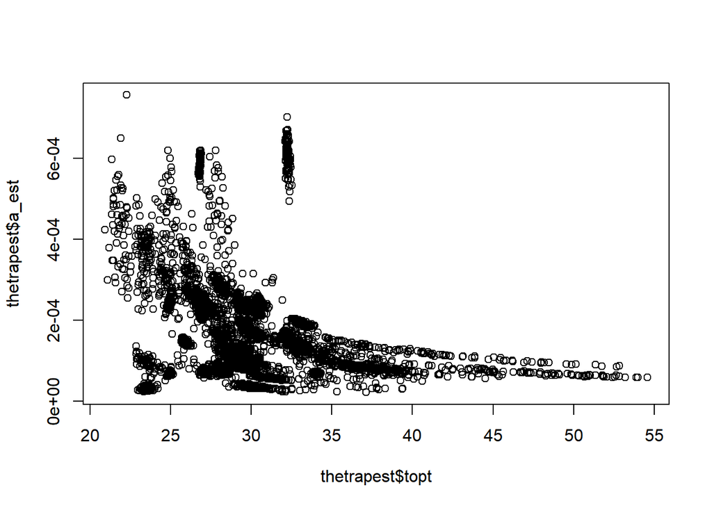

```r
plot(thetrapest$topt,thetrapest$a_est)
```

> Hotter is better for mites

Los ácaros de nuestro dataset pueden servirnos para esto. Podemos ver si a mayor latitud disminuye el r, y también la propia curva para caracterizar ese *hotter is better* de forma precisa. No parece que esto se cumpla…

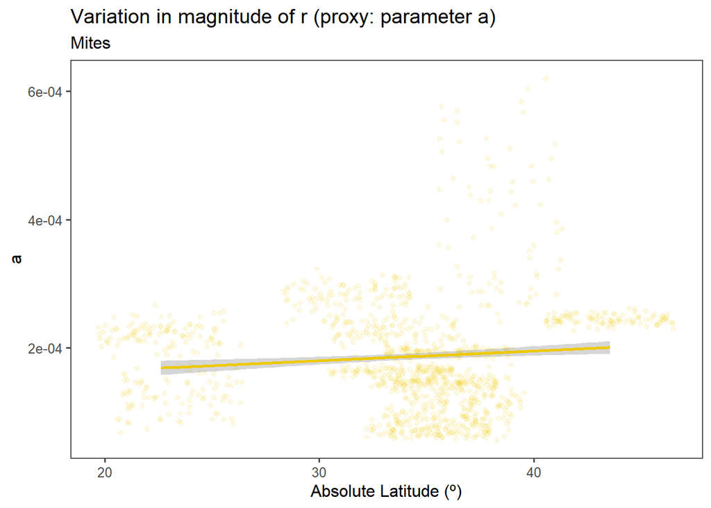

```r
thetrapest_acari <- thetrapest %>%
  filter(order == "Acari")
a_lat_plot <- ggplot(thetrapest_acari,aes(x=abs(lat), y=a_est))+
  geom_point(color="gold2",alpha=0.1, position = position_jitter(width = 3))+
  labs(title = "Variation in magnitude of r (proxy: parameter a)",
       subtitle = "Mites",
       x = "Absolute Latitude (º)",
       y = "a")+
  ggthemes::theme_few()+
  geom_smooth(method = "lm", color = "gold2")
a_lat_plot
```

> ¿Is there a positive correlation between Tmax and r?

Similar a la anterior, en este caso con la máxima.

> Taxa grandes aumentan Tmin más que los taxa pequeños para compensar el déficit que tienen por tamaño.

Asumiendo que lepidoptera son mucho más grandes que ácaros, cabría esperar que los ácaros varíen más sus traits hacia la derecha (ej. más respuesta a la latitud) que las mariposas, para las que el body size tiene mayor impacto relativo en el fitness. Ejemplos: la respuesta a latitud de ácaros debería ser mayor que en lepidópteros, thermal breadth de ácaros también menor que el de lepidópteros (los ácaros estarían más apretados y agobiados con desplazarse en la curva a la derecha). Ver en apartado de thermal breadth y de latitud.

Según Sinclair et al. (2016), la *thermal breadth* la definimos como la distancia entre la temperatura en la que la respuesta es 50% del máximo por el lado izquierdo y la misma por el lado derecho; el **thermal tolerance range** es simplemente *tmax - tmin* y el **thermal safety margin** es *tmax - topt.*

## Heterogeneity of variation:

Aiming to explore biogeographical hypothesis of *cold-tolerance* (Sunday et al. 2011, Sunday et al. 2019, Herrando-Pérez et al. 2020, Bennett et al. 2021), we examined how variability of estimates differs among thermal traits and across covariates such as latitude and order (Deutsch et al. 2008, Buckley et al. 2017). Following Herrando-Pérez et al. (2020) introduction, we examined variability both graphically (using boxplots, pointranges and violinplots) and tests of variance homogeneity such as Levene’s).

### Graphical examination

#### Box | Violin – plots (traits ~ covariates)

- **a) Order**

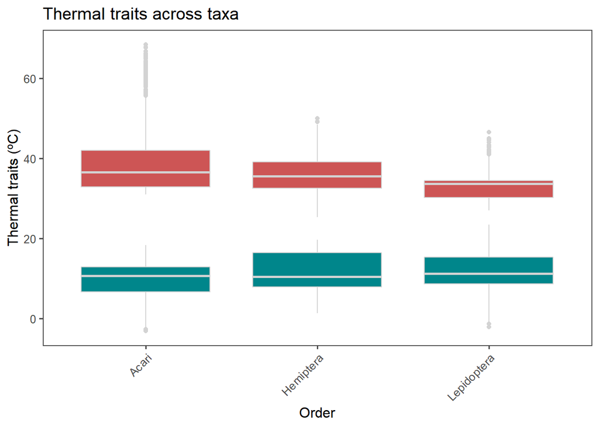

```r
boxplot_traits_ord<- ggplot(data=thetrapest_order, aes(x=order))+
  geom_boxplot(aes(y=tmin),
               fill= "turquoise4",
               color = "lightgrey")+
  geom_boxplot(aes(y=tmax),
               fill="indianred3",
               color = "lightgrey")+
  labs(title = "Thermal traits across taxa",
       x = "Order",
       y = "Thermal traits (ºC)")+
  ggthemes::theme_few()+
  theme(axis.text.x = element_text(angle=45,vjust = 1,hjust=1))+
  theme(legend.position = "none")
boxplot_traits_ord
```

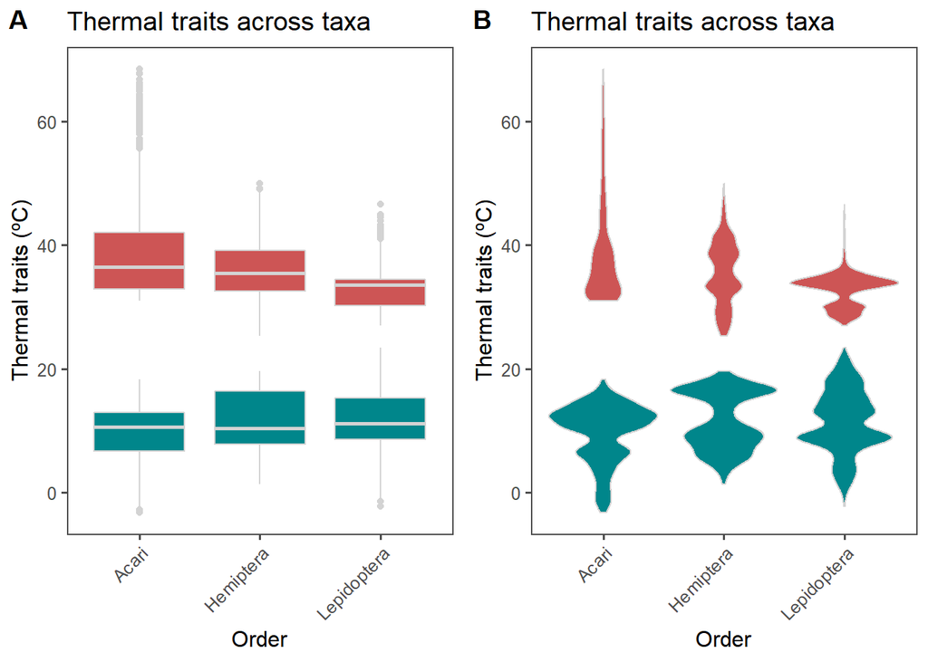

```r
violin_traits_ord <- ggplot(data=thetrapest_order, aes(x=order))+
  geom_violin(aes(y=tmin),
              fill= "turquoise4",
              color = "lightgrey")+
  geom_violin(aes(y=tmax),
              fill="indianred3",
              color = "lightgrey")+
  labs(title = "Thermal traits across taxa",
       x = "Order",
       y = "Thermal traits (ºC)")+
  ggthemes::theme_few()+
  theme(axis.text.x = element_text(angle=45,vjust = 1,hjust=1))+
  theme(legend.position = "none")
grid_hetero_tmin <- plot_grid(boxplot_traits_ord,violin_traits_ord, labels = "AUTO")
grid_hetero_tmin
```

- **b) Feeding guild**

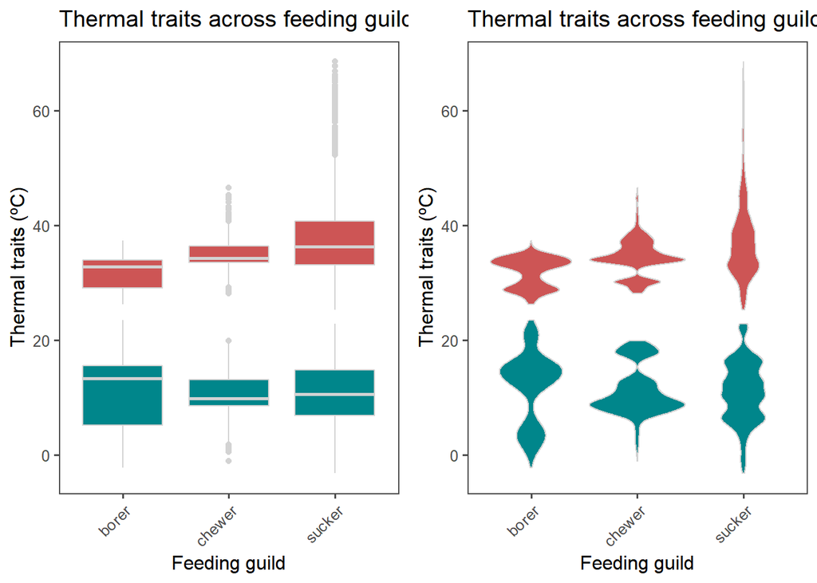

```r
boxplot_traits_fg <- ggplot(data=thetrapest_fg, aes(x=feeding_guild))+
  geom_boxplot(aes(y=tmin),
               fill= "turquoise4",
               color = "lightgrey")+
  geom_boxplot(aes(y=tmax),
               fill="indianred3",
               color = "lightgrey")+
  labs(title = "Thermal traits across feeding guilds",
       x = "Feeding guild",
       y = "Thermal traits (ºC)")+
  ggthemes::theme_few()+
  theme(axis.text.x = element_text(angle=45,vjust = 1,hjust=1))+
  theme(legend.position = "none")
violin_traits_fg <- ggplot(data=thetrapest_fg, aes(x=feeding_guild))+
  geom_violin(aes(y=tmin),
              fill= "turquoise4",
              color = "lightgrey")+
  geom_violin(aes(y=tmax),
              fill="indianred3",
              color = "lightgrey")+
  labs(title = "Thermal traits across feeding guilds",
       x = "Feeding guild",
       y = "Thermal traits (ºC)")+
  ggthemes::theme_few()+
  theme(axis.text.x = element_text(angle=45,vjust = 1,hjust=1))+
  theme(legend.position = "none")
plot_hetero_fg <- plot_grid(boxplot_traits_fg,violin_traits_fg)
plot_hetero_fg
```

#### Traits variability along latitude

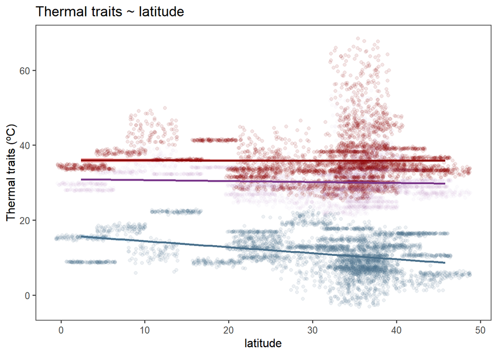

```r
# ~~~~~~~~ (3) traits variability ~ lat ~----
all_lms_combined <- ggplot(thetrapest)+
  geom_point(aes(x=abs(lat),y=tmin),color="skyblue4",alpha=0.1, position = position_jitter(width = 3))+
  geom_smooth(aes(x=abs(lat),y=tmin),color="skyblue4",fill="skyblue2", method = "lm")+
  geom_point(aes(x=abs(lat),y=tmax),color="red4",alpha=0.1, position = position_jitter(width = 3))+
  geom_smooth(aes(x=abs(lat),y=tmax),color="red4",fill="red3", method = "lm")+
  geom_point(aes(x=abs(lat),y=topt),color="mediumorchid4",alpha=0.02, position = position_jitter(width = 3))+
  geom_smooth(aes(x=abs(lat),y=topt),color="mediumorchid4",fill="mediumorchid3", method = "lm", alpha = 0.01)+
  labs(title= "Thermal traits ~ latitude",x= "latitude",y= "Thermal traits (ºC)")+
  theme_few()
all_lms_combined
```

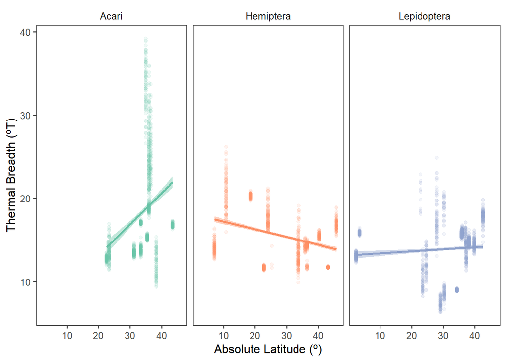

```r
breadth_order_lat <- ggplot(data = thetrapest_order, aes(abs(lat), thermal_breadth))+
  geom_point(aes(color = order), alpha =0.1)+
  facet_wrap(.~order)+
  geom_smooth(aes(color = order, fill = order), method = "lm")+
  theme_few()+
  scale_color_brewer(palette = "Set2")+
  scale_fill_brewer(palette = "Set2")+
  theme(legend.position = "none")+
  labs(x = "Absolute Latitude (º)",
       y = "Thermal Breadth (ºT)")
breadth_order_lat
```

#### traits variability ~ 1 (no covariate)

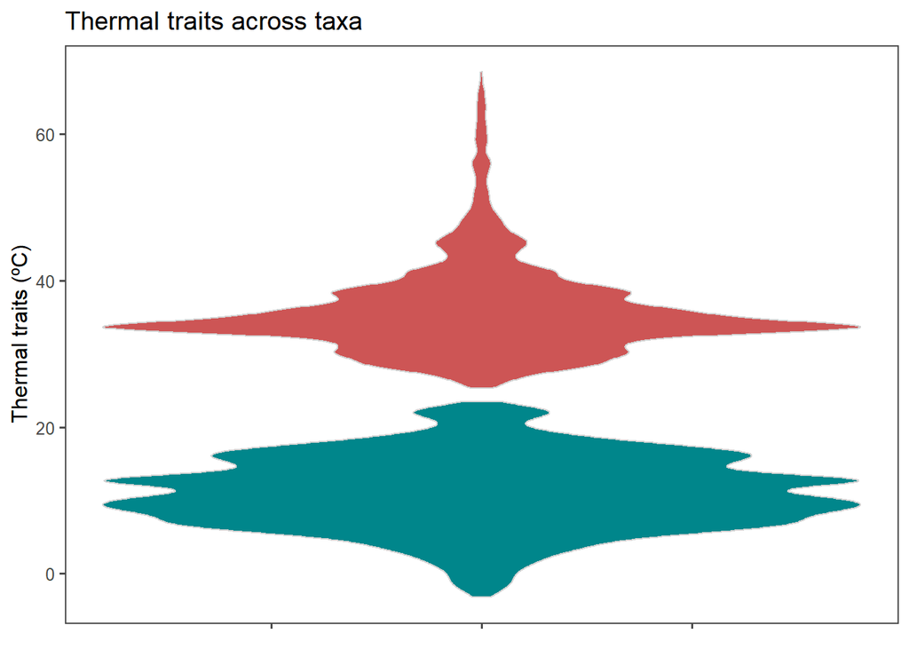

```r
violin_traits_all <- ggplot(data=thetrapest,aes(x=1))+
  geom_violin(aes(y=tmin),
              fill= "turquoise4",
              color = "lightgrey")+
  geom_violin(aes(y=tmax),
              fill="indianred3",
              color = "lightgrey")+
  labs(title = "Thermal traits across taxa",
       x = element_blank(),
       y = "Thermal traits (ºC)")+
  ggthemes::theme_few()+
  theme(axis.text.x = element_blank())+
  theme(legend.position = "none")
violin_traits_all
```

### Quantitative Analysis of heterogeneity

We aim to evaluate whether lower and upper thermal traits’ variabilities differ. First we perform a F-test, similarly to Herrando-Pérez et al. (2020)

```r
# ~~~~~~~~  (1) F-test (see Herrando-Pérez, 2019) ----
variances_tmin <- thetrapest %>%
  select(tmin, vi, id) %>%
  mutate(parameter = rep("tmin")) %>%
  rename(estimate = tmin)
variances_tmax <- thetrapest %>%
  select(tmax, vi, id) %>%
  mutate(parameter = rep("tmax")) %>%
  rename(estimate = tmax)
variances_traits = variances_tmin %>%
  bind_rows(variances_tmax)
#test variance differences
var.test(estimate ~ parameter, variances_traits,
         alternative = "greater") #que tmin tiene más varianza que tmax
```

```
##
##  F test to compare two variances
##
## data:  estimate by parameter
## F = 1.5791, num df = 4119, denom df = 4119, p-value < 2.2e-16
## alternative hypothesis: true ratio of variances is greater than 1
## 95 percent confidence interval:
##  1.500171      Inf
## sample estimates:
## ratio of variances
##           1.579081
```

```r
# ~~~~~~~~  (2) Levene's test (see Hoffmann, 2013) ----
leveneTest(y = estimate ~ parameter, data = variances_traits) # also
```

```
## Levene's Test for Homogeneity of Variance (center = median)
##         Df F value Pr(>F)
## group    1  5.2241 0.0223 *
##       8238
## ---
## Signif. codes:  0 '***' 0.001 '**' 0.01 '*' 0.05 '.' 0.1 ' ' 1
```

Next, we use the meta-analysis *true* between-studies heterogeneity (i.e. 𝜏). In this case, we standardise the value by dividing the 𝜏 by the estimate.

```r
# ~~~~~~~~ (3) lme modelling output ----
lme_4vars <- lme(tmin ~ 1,
                 random = ~1|id,
                 weights = varFixed(~vi),
                 control = lmeControl(sigma = 1),
                 data = thetrapest)
lme_4vars2 <- lme(tmax ~ 1,
                 random = ~1|id,
                 weights = varFixed(~vi),
                 control = lmeControl(sigma = 1),
                 data = thetrapest)


tau_rel_tmin <- as.numeric(VarCorr(lme_4vars)[1,2])/lme_4vars$coefficients$fixed
tau_rel_tmax <- as.numeric(VarCorr(lme_4vars2)[1,2])/lme_4vars2$coefficients$fixed
# similar...
```

# References

Araújo, M. B. et al. 2013. Heat freezes niche evolution. - Ecology Letters 16: 1206–1219.

Bennett, J. M. et al. 2021. The evolution of critical thermal limits of life on Earth. - Nature Communications 12: 1198.

Buckley, L. B. et al. 2017. Insect Development, Thermal Plasticity and Fitness Implications in Changing, Seasonal Environments. - Integrative and Comparative Biology 57: 988–998.

Deutsch, C. A. et al. 2008. Impacts of climate warming on terrestrial ectotherms across latitude. - Proceedings of the National Academy of Sciences 105: 6668–6672.

Ettinger, A. K. et al. 2020. Winter temperatures predominate in spring phenological responses to warming. - Nature Climate Change 10: 1137–1142.

Frazier, M. R. et al. 2006. Thermodynamics constrains the evolution of insect population growth rates: "warmer is better". - The American Naturalist 168: 512–520.

Herrando-Pérez, S. et al. 2020. Heat tolerance is more variable than cold tolerance across species of Iberian lizards after controlling for intraspecific variation. - Functional Ecology 34: 631–645.

Hoffmann, A. A. et al. 2013. Upper thermal limits in terrestrial ectotherms: how constrained are they? - Functional Ecology 27: 934–949.

Kharouba, H. M. et al. 2018. Global shifts in the phenological synchrony of species interactions over recent decades. - Proceedings of the National Academy of Sciences 115: 5211–5216.

Kingsolver, J. G. and Huey, R. B. Size, temperature, and fitness: three rules.: 18.

2013. Handbook of Meta-analysis in Ecology and Evolution (J Koricheva, J Gurevitch, and K Mengersen, Eds.). - Princeton University Press.

Koricheva, J. and Gurevitch, J. 2014. Uses and misuses of meta-analysis in plant ecology. - Journal of Ecology 102: 828–844.

Mengersen, K. and Schmid, C. H. 2013. Maximum Likelihood Approaches to Meta-analysis. - In: Princeton University Press, in press.

Schmid, C. H. and Mengersen, K. 2013. Bayesian Meta-analysis. - In: Princeton University Press, in press.

Sinclair, B. J. et al. 2016. Can we predict ectotherm responses to climate change using thermal performance curves and body temperatures? - Ecology Letters 19: 1372–1385.

Sunday, J. M. et al. 2011. Global analysis of thermal tolerance and latitude in ectotherms. - Proceedings of the Royal Society B: Biological Sciences 278: 1823–1830.

Sunday, J. et al. 2019. Thermal tolerance patterns across latitude and elevation. - Philosophical Transactions of the Royal Society B: Biological Sciences 374: 20190036.

Zuur, A. F. et al. 2009. Mixed Effects Modelling for Nested Data. - In: Zuur, A. F. et al. (eds), Statistics for Biology and Health. Springer, pp. 101–142.